# Homework Week 8 - Data Exploration and Summary

# Background

This week we will use a real data set of course data from 614 undergraduate students. The data consists of students’ scores on different course assignments, as well as several background variables collected for research purposes.

The data set can be downloaded from the github repo here: https://github.com/making-data-science-count/s21-intro-to-data-sci-methods-in-ed/blob/main/data/undergrad_data.csv

The data consists of an identifier, columns on project scores, a total course points column, columns on exam scores, scores on a pre and post problem solving ability test, 5 personality trait variables, and 4 motivation variables.

# Loading data

Download the .csv file and then load it in this chunk. But first, load the packages you will need (you can always come back and add more):

Once you’ve loaded it, familiarize yourself with the different variables in the data set using the methods for inspecting and exploring a new data set we have discussed, particularly using the `visdat` package.

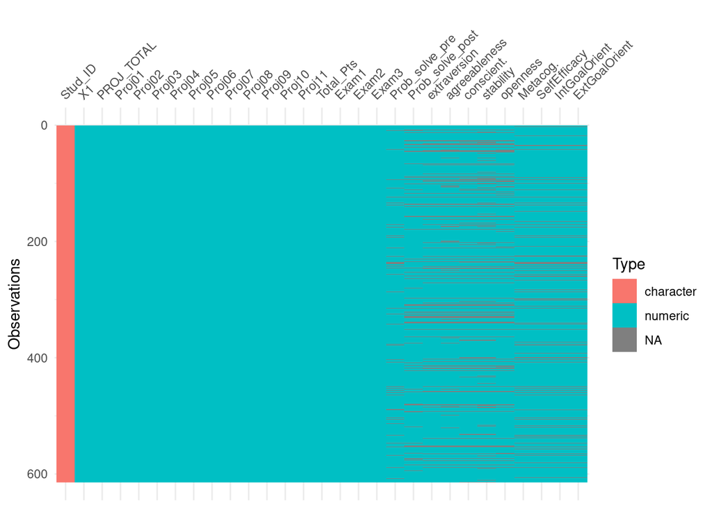

```
## Rows: 614
## Columns: 29
## $ X1              <dbl> 1, 2, 3, 4, 5, 6, 7, 8, 9, 10, 11, 12, 13, 14, 15, 16,…
## $ Stud_ID         <chr> "e75ab8254", "07ee7a263", "9c02eb000", "52fb2d1ca", "a…
## $ PROJ_TOTAL      <dbl> 347, 427, 393, 397, 316, 435, 375, 398, 350, 354, 295,…
## $ Proj01          <dbl> 14, 14, 14, 14, 14, 14, 13, 14, 14, 13, 13, 14, 14, 14…
## $ Proj02          <dbl> 19, 20, 18, 18, 20, 20, 20, 17, 18, 18, 20, 20, 12, 20…
## $ Proj03          <dbl> 13, 20, 16, 19, 12, 19, 20, 19, 18, 17, 20, 20, 0, 20,…
## $ Proj04          <dbl> 25, 38, 37, 0, 36, 36, 36, 39, 37, 32, 34, 40, 26, 38,…
## $ Proj05          <dbl> 27, 45, 42, 43, 8, 45, 43, 45, 44, 40, 43, 45, 0, 44, …
## $ Proj06          <dbl> 35, 42, 44, 43, 34, 45, 38, 41, 0, 33, 41, 45, 0, 45, …
## $ Proj07          <dbl> 40, 41, 45, 50, 0, 50, 46, 49, 45, 16, 50, 50, 0, 50, …
## $ Proj08          <dbl> 47, 50, 41, 50, 41, 50, 40, 20, 43, 39, 19, 48, 0, 48,…
## $ Proj09          <dbl> 44, 52, 50, 52, 52, 55, 50, 55, 51, 52, 55, 55, 0, 55,…
## $ Proj10          <dbl> 35, 53, 37, 53, 49, 46, 22, 47, 40, 40, 0, 48, 0, 53, …
```

[output cut: 16 more lines]

```
##        X1          Stud_ID            PROJ_TOTAL        Proj01
##  Min.   :  1.0   Length:614         Min.   :  0.0   Min.   : 0.0
##  1st Qu.:154.2   Class :character   1st Qu.:354.0   1st Qu.:14.0
##  Median :307.5   Mode  :character   Median :407.0   Median :15.0
##  Mean   :307.5                      Mean   :370.7   Mean   :13.8
##  3rd Qu.:460.8                      3rd Qu.:437.0   3rd Qu.:15.0
##  Max.   :614.0                      Max.   :450.0   Max.   :15.0
##
##      Proj02          Proj03          Proj04          Proj05
##  Min.   : 0.00   Min.   : 0.00   Min.   : 0.00   Min.   : 0.00
##  1st Qu.:18.00   1st Qu.:14.00   1st Qu.:30.00   1st Qu.:34.00
##  Median :20.00   Median :18.00   Median :38.00   Median :43.00
##  Mean   :17.84   Mean   :15.49   Mean   :31.95   Mean   :35.67
##  3rd Qu.:20.00   3rd Qu.:20.00   3rd Qu.:40.00   3rd Qu.:45.00
##  Max.   :20.00   Max.   :20.00   Max.   :40.00   Max.   :45.00
##
##      Proj06          Proj07       Proj08          Proj09          Proj10
##  Min.   : 0.00   Min.   : 0   Min.   : 0.00   Min.   : 0.00   Min.   : 0.00
##  1st Qu.:38.00   1st Qu.:43   1st Qu.:40.00   1st Qu.:50.00   1st Qu.:40.00
##  Median :43.00   Median :49   Median :48.00   Median :54.00   Median :50.00
##  Mean   :37.16   Mean   :42   Mean   :40.17   Mean   :47.39   Mean   :42.56
##  3rd Qu.:45.00   3rd Qu.:50   3rd Qu.:50.00   3rd Qu.:55.00   3rd Qu.:54.00
##  Max.   :45.00   Max.   :50   Max.   :50.00   Max.   :55.00   Max.   :55.00
##
##      Proj11        Total_Pts         Exam1            Exam2
##  Min.   : 0.00   Min.   :  0.0   Min.   :  0.00   Min.   :  0.0
##  1st Qu.:51.00   1st Qu.:722.0   1st Qu.: 64.00   1st Qu.: 95.0
##  Median :55.00   Median :814.5   Median : 72.00   Median :115.0
##  Mean   :46.71   Mean   :763.5   Mean   : 71.81   Mean   :111.6
##  3rd Qu.:55.00   3rd Qu.:880.8   3rd Qu.: 84.00   3rd Qu.:130.0
##  Max.   :55.00   Max.   :982.0   Max.   :100.00   Max.   :150.0
##
##      Exam3       Prob_solve_pre   Prob_solve_post  extraversion
##  Min.   :  0.0   Min.   : 0.000   Min.   : 0.00   Min.   :10.00
##  1st Qu.:101.0   1st Qu.: 5.917   1st Qu.: 6.50   1st Qu.:34.00
##  Median :125.5   Median : 9.500   Median :11.33   Median :40.00
##  Mean   :121.4   Mean   : 9.543   Mean   :10.76   Mean   :40.03
##  3rd Qu.:150.0   3rd Qu.:13.000   3rd Qu.:15.00   3rd Qu.:46.00
##  Max.   :190.0   Max.   :22.000   Max.   :22.00   Max.   :67.00
##                  NA's   :43       NA's   :63      NA's   :74
##  agreeableness     conscient.     stability        openness        Metacog.
##  Min.   :22.00   Min.   :22.0   Min.   :11.00   Min.   :23.00   Min.   :16.00
##  1st Qu.:43.00   1st Qu.:40.0   1st Qu.:38.00   1st Qu.:41.00   1st Qu.:41.00
##  Median :50.00   Median :47.0   Median :44.00   Median :48.00   Median :47.00
##  Mean   :49.02   Mean   :46.8   Mean   :43.51   Mean   :47.85   Mean   :46.86
##  3rd Qu.:56.00   3rd Qu.:52.0   3rd Qu.:51.00   3rd Qu.:53.00   3rd Qu.:53.00
##  Max.   :70.00   Max.   :70.0   Max.   :68.00   Max.   :69.00   Max.   :70.00
##  NA's   :90      NA's   :88     NA's   :110     NA's   :85      NA's   :67
##   SelfEfficacy   IntGoalOrient   ExtGoalOrient
##  Min.   : 8.00   Min.   : 4.00   Min.   : 4.00
##  1st Qu.:36.00   1st Qu.:16.00   1st Qu.:19.00
##  Median :44.00   Median :20.00   Median :23.00
##  Mean   :42.17   Mean   :19.57   Mean   :22.06
##  3rd Qu.:48.00   3rd Qu.:23.00   3rd Qu.:25.50
##  Max.   :56.00   Max.   :28.00   Max.   :28.00
##  NA's   :67      NA's   :67      NA's   :67
```

What are some observations you made about the data from your exploration?

# Data Report

We would now like you to use the undergrad data to produce a report including the following elements:

# Summary table

Make a nicely styled summary table using the `kable()` function from the `knitr` package, using whichever summary function you want (check the slides from this week to see the different options we discussed). But first be sure to exclude any variables where it doesn’t make sense to have a numeric summary, e.g. character variables.

|  | vars | n | mean | sd | median | trimmed | mad | min | max | range | skew | kurtosis | se |
| --- | --- | --- | --- | --- | --- | --- | --- | --- | --- | --- | --- | --- | --- |
| X1 | 1 | 614 | 307.500000 | 177.390812 | 307.50000 | 307.500000 | 227.5791 | 1 | 614 | 613 | 0.0000000 | -1.2058648 | 7.1589105 |
| Stud_ID* | 2 | 614 | 307.500000 | 177.390812 | 307.50000 | 307.500000 | 227.5791 | 1 | 614 | 613 | 0.0000000 | -1.2058648 | 7.1589105 |
| PROJ_TOTAL | 3 | 614 | 370.739414 | 101.024332 | 407.00000 | 393.483740 | 50.4084 | 0 | 450 | 450 | -2.0258542 | 3.6017748 | 4.0770102 |
| Proj01 | 4 | 614 | 13.798046 | 3.055484 | 15.00000 | 14.540650 | 0.0000 | 0 | 15 | 15 | -3.8394447 | 14.2771579 | 0.1233093 |
| Proj02 | 5 | 614 | 17.837134 | 4.090676 | 20.00000 | 18.853659 | 0.0000 | 0 | 20 | 20 | -2.9743310 | 9.1487156 | 0.1650862 |
| Proj03 | 6 | 614 | 15.488599 | 5.637705 | 18.00000 | 16.630081 | 2.9652 | 0 | 20 | 20 | -1.5106610 | 1.4965899 | 0.2275193 |
| Proj04 | 7 | 614 | 31.951140 | 11.811774 | 38.00000 | 34.642276 | 2.9652 | 0 | 40 | 40 | -1.6660662 | 1.5908529 | 0.4766844 |
| Proj05 | 8 | 614 | 35.671010 | 14.338915 | 43.00000 | 38.888211 | 2.9652 | 0 | 45 | 45 | -1.6161892 | 1.1775038 | 0.5786715 |
| Proj06 | 9 | 614 | 37.161238 | 13.146498 | 43.00000 | 40.420732 | 2.9652 | 0 | 45 | 45 | -1.8861397 | 2.2375605 | 0.5305495 |
| Proj07 | 10 | 614 | 42.004886 | 14.462698 | 49.00000 | 45.745935 | 1.4826 | 0 | 50 | 50 | -1.9730013 | 2.6173758 | 0.5836670 |
| Proj08 | 11 | 614 | 40.169381 | 15.779599 | 48.00000 | 43.833333 | 2.9652 | 0 | 50 | 50 | -1.6940649 | 1.4102676 | 0.6368128 |
| Proj09 | 12 | 614 | 47.385993 | 15.470833 | 54.00000 | 51.886179 | 1.4826 | 0 | 55 | 55 | -2.3624424 | 4.1600537 | 0.6243520 |
| Proj10 | 13 | 614 | 42.557003 | 17.200929 | 50.00000 | 46.284553 | 7.4130 | 0 | 55 | 55 | -1.6150323 | 1.2696061 | 0.6941730 |
| Proj11 | 14 | 614 | 46.714984 | 17.068097 | 55.00000 | 51.426829 | 0.0000 | 0 | 55 | 55 | -2.0627940 | 2.6846906 | 0.6888123 |
| Total_Pts | 15 | 614 | 763.500000 | 179.761204 | 814.50000 | 797.282520 | 114.1602 | 0 | 982 | 982 | -1.9788365 | 4.1671908 | 7.2545718 |
| Exam1 | 16 | 614 | 71.811075 | 15.660035 | 72.00000 | 73.105691 | 11.8608 | 0 | 100 | 100 | -1.3501699 | 3.8594716 | 0.6319876 |
| Exam2 | 17 | 614 | 111.636808 | 26.790834 | 115.00000 | 114.156504 | 29.6520 | 0 | 150 | 150 | -1.4238620 | 3.7206145 | 1.0811901 |
| Exam3 | 18 | 614 | 121.403909 | 39.232811 | 125.50000 | 125.237805 | 36.3237 | 0 | 190 | 190 | -1.1162585 | 1.6694973 | 1.5833074 |
| Prob_solve_pre | 19 | 571 | 9.543491 | 5.074475 | 9.50000 | 9.461707 | 5.1891 | 0 | 22 | 22 | 0.1222171 | -0.6859780 | 0.2123602 |
| Prob_solve_post | 20 | 551 | 10.759528 | 5.890859 | 11.33333 | 10.866969 | 6.4246 | 0 | 22 | 22 | -0.1591616 | -0.8794690 | 0.2509590 |
| extraversion | 21 | 540 | 40.033333 | 10.319515 | 40.00000 | 40.097222 | 8.8956 | 10 | 67 | 57 | -0.0787788 | 0.0461230 | 0.4440812 |
| agreeableness | 22 | 524 | 49.017176 | 8.556286 | 50.00000 | 49.183333 | 10.3782 | 22 | 70 | 48 | -0.2292123 | -0.3395478 | 0.3737831 |
| conscient. | 23 | 526 | 46.796578 | 8.331150 | 47.00000 | 46.744076 | 8.8956 | 22 | 70 | 48 | 0.0059412 | -0.1685668 | 0.3632554 |
| stability | 24 | 504 | 43.507936 | 10.133696 | 44.00000 | 43.898515 | 9.6369 | 11 | 68 | 57 | -0.3660818 | 0.0775995 | 0.4513907 |
| openness | 25 | 529 | 47.848771 | 7.990276 | 48.00000 | 47.647059 | 8.8956 | 23 | 69 | 46 | 0.1410262 | -0.4259745 | 0.3474033 |
| Metacog. | 26 | 547 | 46.855576 | 9.180086 | 47.00000 | 46.895216 | 8.8956 | 16 | 70 | 54 | -0.0723540 | 0.1774336 | 0.3925121 |
| SelfEfficacy | 27 | 547 | 42.168190 | 8.928135 | 44.00000 | 42.587699 | 8.8956 | 8 | 56 | 48 | -0.5389725 | 0.0633165 | 0.3817395 |
| IntGoalOrient | 28 | 547 | 19.572212 | 4.658660 | 20.00000 | 19.744875 | 4.4478 | 4 | 28 | 24 | -0.3770214 | 0.0293435 | 0.1991899 |
| ExtGoalOrient | 29 | 547 | 22.058501 | 4.466835 | 23.00000 | 22.371298 | 4.4478 | 4 | 28 | 24 | -0.7035298 | 0.4828373 | 0.1909881 |

Now please use the `kableExtra` package to make some additional formatting tweaks. highlight the lowest and highest values of some column of your choice using the `row_spec()` or `cell_spec()` functions, and then make one other formatting addition of your choice, like a title or a footnote or whatever you want.

Summary Table: Undergrad data

|  | vars | n | mean | sd | median | trimmed | mad | min | max | range | skew | kurtosis | se |
| --- | --- | --- | --- | --- | --- | --- | --- | --- | --- | --- | --- | --- | --- |
| X1 | 1 | 614 | 307.500000 | 177.390812 | 307.50000 | 307.500000 | 227.5791 | 1 | 614 | 613 | 0.0000000 | -1.2058648 | 7.1589105 |
| Stud_ID* | 2 | 614 | 307.500000 | 177.390812 | 307.50000 | 307.500000 | 227.5791 | 1 | 614 | 613 | 0.0000000 | -1.2058648 | 7.1589105 |
| PROJ_TOTAL | 3 | 614 | 370.739414 | 101.024332 | 407.00000 | 393.483740 | 50.4084 | 0 | 450 | 450 | -2.0258542 | 3.6017748 | 4.0770102 |
| Proj01 | 4 | 614 | 13.798046 | 3.055484 | 15.00000 | 14.540650 | 0.0000 | 0 | 15 | 15 | -3.8394447 | 14.2771579 | 0.1233093 |
| Proj02 | 5 | 614 | 17.837134 | 4.090676 | 20.00000 | 18.853659 | 0.0000 | 0 | 20 | 20 | -2.9743310 | 9.1487156 | 0.1650862 |
| Proj03 | 6 | 614 | 15.488599 | 5.637705 | 18.00000 | 16.630081 | 2.9652 | 0 | 20 | 20 | -1.5106610 | 1.4965899 | 0.2275193 |
| Proj04 | 7 | 614 | 31.951140 | 11.811774 | 38.00000 | 34.642276 | 2.9652 | 0 | 40 | 40 | -1.6660662 | 1.5908529 | 0.4766844 |
| Proj05 | 8 | 614 | 35.671010 | 14.338915 | 43.00000 | 38.888211 | 2.9652 | 0 | 45 | 45 | -1.6161892 | 1.1775038 | 0.5786715 |
| Proj06 | 9 | 614 | 37.161238 | 13.146498 | 43.00000 | 40.420732 | 2.9652 | 0 | 45 | 45 | -1.8861397 | 2.2375605 | 0.5305495 |
| Proj07 | 10 | 614 | 42.004886 | 14.462698 | 49.00000 | 45.745935 | 1.4826 | 0 | 50 | 50 | -1.9730013 | 2.6173758 | 0.5836670 |
| Proj08 | 11 | 614 | 40.169381 | 15.779599 | 48.00000 | 43.833333 | 2.9652 | 0 | 50 | 50 | -1.6940649 | 1.4102676 | 0.6368128 |
| Proj09 | 12 | 614 | 47.385993 | 15.470833 | 54.00000 | 51.886179 | 1.4826 | 0 | 55 | 55 | -2.3624424 | 4.1600537 | 0.6243520 |
| Proj10 | 13 | 614 | 42.557003 | 17.200929 | 50.00000 | 46.284553 | 7.4130 | 0 | 55 | 55 | -1.6150323 | 1.2696061 | 0.6941730 |
| Proj11 | 14 | 614 | 46.714984 | 17.068097 | 55.00000 | 51.426829 | 0.0000 | 0 | 55 | 55 | -2.0627940 | 2.6846906 | 0.6888123 |
| Total_Pts | 15 | 614 | 763.500000 | 179.761204 | 814.50000 | 797.282520 | 114.1602 | 0 | 982 | 982 | -1.9788365 | 4.1671908 | 7.2545718 |
| Exam1 | 16 | 614 | 71.811075 | 15.660035 | 72.00000 | 73.105691 | 11.8608 | 0 | 100 | 100 | -1.3501699 | 3.8594716 | 0.6319876 |
| Exam2 | 17 | 614 | 111.636808 | 26.790834 | 115.00000 | 114.156504 | 29.6520 | 0 | 150 | 150 | -1.4238620 | 3.7206145 | 1.0811901 |
| Exam3 | 18 | 614 | 121.403909 | 39.232811 | 125.50000 | 125.237805 | 36.3237 | 0 | 190 | 190 | -1.1162585 | 1.6694973 | 1.5833074 |
| Prob_solve_pre | 19 | 571 | 9.543491 | 5.074475 | 9.50000 | 9.461707 | 5.1891 | 0 | 22 | 22 | 0.1222171 | -0.6859780 | 0.2123602 |
| Prob_solve_post | 20 | 551 | 10.759528 | 5.890859 | 11.33333 | 10.866969 | 6.4246 | 0 | 22 | 22 | -0.1591616 | -0.8794690 | 0.2509590 |
| extraversion | 21 | 540 | 40.033333 | 10.319515 | 40.00000 | 40.097222 | 8.8956 | 10 | 67 | 57 | -0.0787788 | 0.0461230 | 0.4440812 |
| agreeableness | 22 | 524 | 49.017176 | 8.556286 | 50.00000 | 49.183333 | 10.3782 | 22 | 70 | 48 | -0.2292123 | -0.3395478 | 0.3737831 |
| conscient. | 23 | 526 | 46.796578 | 8.331150 | 47.00000 | 46.744076 | 8.8956 | 22 | 70 | 48 | 0.0059412 | -0.1685668 | 0.3632554 |
| stability | 24 | 504 | 43.507936 | 10.133696 | 44.00000 | 43.898515 | 9.6369 | 11 | 68 | 57 | -0.3660818 | 0.0775995 | 0.4513907 |
| openness | 25 | 529 | 47.848771 | 7.990276 | 48.00000 | 47.647059 | 8.8956 | 23 | 69 | 46 | 0.1410262 | -0.4259745 | 0.3474033 |
| Metacog. | 26 | 547 | 46.855576 | 9.180086 | 47.00000 | 46.895216 | 8.8956 | 16 | 70 | 54 | -0.0723540 | 0.1774336 | 0.3925121 |
| SelfEfficacy | 27 | 547 | 42.168190 | 8.928135 | 44.00000 | 42.587699 | 8.8956 | 8 | 56 | 48 | -0.5389725 | 0.0633165 | 0.3817395 |
| IntGoalOrient | 28 | 547 | 19.572212 | 4.658660 | 20.00000 | 19.744875 | 4.4478 | 4 | 28 | 24 | -0.3770214 | 0.0293435 | 0.1991899 |
| ExtGoalOrient | 29 | 547 | 22.058501 | 4.466835 | 23.00000 | 22.371298 | 4.4478 | 4 | 28 | 24 | -0.7035298 | 0.4828373 | 0.1909881 |

# Correlation Matrix

Make a correlation matrix, including only the 11 individual project score variables, and style that output nicely.

```
## # A tibble: 11 x 12
##    term   Proj01 Proj02 Proj03 Proj04 Proj05 Proj06 Proj07 Proj08 Proj09 Proj10
##    <chr>   <dbl>  <dbl>  <dbl>  <dbl>  <dbl>  <dbl>  <dbl>  <dbl>  <dbl>  <dbl>
##  1 Proj01 NA      0.341  0.287  0.233  0.277  0.253  0.294  0.279  0.200  0.203
##  2 Proj02  0.341 NA      0.423  0.414  0.343  0.387  0.385  0.383  0.362  0.304
##  3 Proj03  0.287  0.423 NA      0.476  0.439  0.426  0.411  0.428  0.417  0.375
##  4 Proj04  0.233  0.414  0.476 NA      0.453  0.498  0.446  0.493  0.474  0.446
##  5 Proj05  0.277  0.343  0.439  0.453 NA      0.561  0.514  0.509  0.508  0.502
##  6 Proj06  0.253  0.387  0.426  0.498  0.561 NA      0.621  0.650  0.649  0.616
##  7 Proj07  0.294  0.385  0.411  0.446  0.514  0.621 NA      0.611  0.620  0.568
##  8 Proj08  0.279  0.383  0.428  0.493  0.509  0.650  0.611 NA      0.681  0.628
##  9 Proj09  0.200  0.362  0.417  0.474  0.508  0.649  0.620  0.681 NA      0.653
## 10 Proj10  0.203  0.304  0.375  0.446  0.502  0.616  0.568  0.628  0.653 NA
## 11 Proj11  0.306  0.368  0.396  0.455  0.498  0.658  0.658  0.660  0.652  0.714
## # … with 1 more variable: Proj11 <dbl>
```

Now use the `corrr` package to produce a correlation heat map for the correlation matrix you just made, and use the lower triangle only.

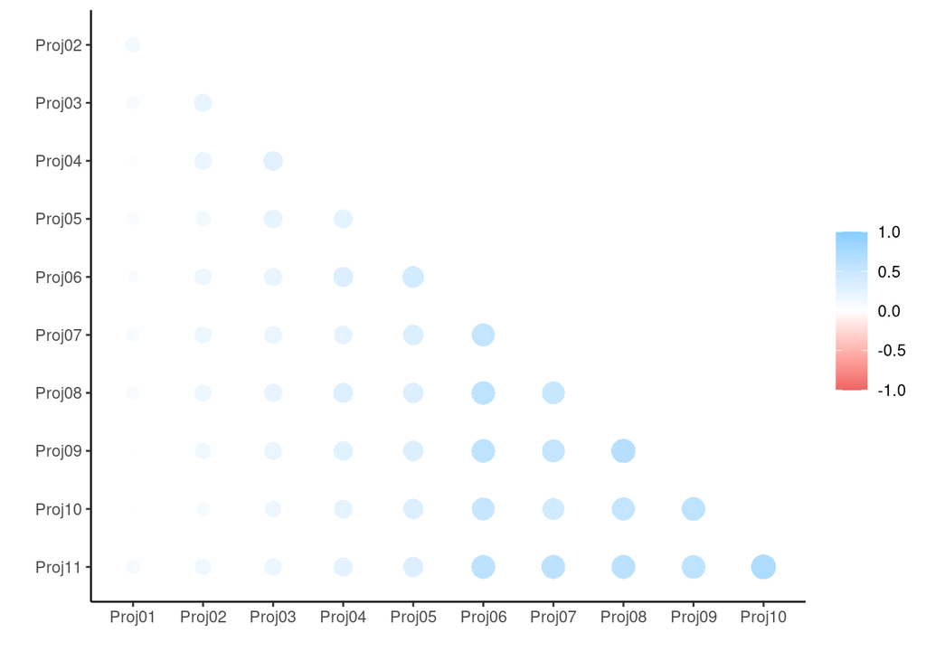

# Regression model

Run a regression model using `lm()` with the `Total_Pts` variable as the dependent variable, plus whichever independent variables you want. If you have questions about how to use `lm()` to specify models, just Google “lm syntax r”.

Now use the `sjPlot` package to create a nice output table for your `lm()` model as we showed in class.

|  | Total Pts |  |  |
| --- | --- | --- | --- |
| Predictors | Estimates | CI | p |
| (Intercept) | 798.16 | 726.45 – 869.86 | **<0.001** |
| extraversion | -0.67 | -1.82 – 0.47 | 0.248 |
| agreeableness | 0.44 | -0.95 – 1.84 | 0.531 |
| Observations | 524 |  |  |
| R<sup>2</sup> / R<sup>2</sup> adjusted | 0.003 / -0.001 |  |  |

Now we have one last task for you that may be a bit harder. We would like you to create a composite variable by creating a sum of the 3 exam score variables in the data set.

We didn’t cover this in class, but here’s a stackoverflow post where a few different answers using different methods are provided: https://stackoverflow.com/questions/10945703/calculate-row-means-on-subset-of-columns

Now make a new `lm()` model, using this composite variable as the dependent variable, and generate the output table using the `sjPlot` package just as in the last step.

|  | exam total |  |  |
| --- | --- | --- | --- |
| Predictors | Estimates | CI | p |
| (Intercept) | 339.37 | 307.28 – 371.45 | **<0.001** |
| extraversion | -0.46 | -0.97 – 0.05 | 0.077 |
| agreeableness | -0.12 | -0.75 – 0.50 | 0.696 |
| Observations | 524 |  |  |
| R<sup>2</sup> / R<sup>2</sup> adjusted | 0.008 / 0.004 |  |  |

# Reach 1

Use the `apaTables` package to make a regression table of your `lm()` model from above in the APA format.

# Reach 2

Remake the correlation matrix from above using only the values that are not equal to 0. Also generate the significance values of the correlations.

http://www.sthda.com/english/wiki/correlation-matrix-a-quick-start-guide-to-analyze-format-and-visualize-a-correlation-matrix-using-r-software#correlation-matrix-with-significance-levels-p-value

## fin

Render and submit: - Submit the .html file you used to render a report to Canvas - Upload the .Rmd file you rendered to the #homework channel in Slack. One difference from last week: Please post a comment, feedback, or reflection below *as well as to Slack when you post your homework*.

## Self-assessment and reflection

Respond to the following three questions on a 1 (not at all) to 5 (very much) scale by replacing the “x” below with your response:

```
## # A tibble: 3 x 2
##   question                                  response
##   <chr>                                     <list>
## 1 How challenging was this homework?        <NULL>
## 2 How interesting was this homework to you? <NULL>
## 3 How valuable was this homework to you?    <NULL>
```

Include any other comments, feedback, or reflections on this homework below:

Important note: Please post your comment(s), feedback, or reflections in Slack when you share your Rmd file!